# STT 301 Homework Assignment 1

Rellika Kisyula

September 10, 2018

### Question 1 (3 points)

This question focuses on some basic manipulations of vectors in R.

#### Part a (1 point)

Create four vectors in R: one called `nums` which contains the integers from 5 through 14; one called `charnums` which contains character representations of the numbers 1 through 4, namely, “1”, “2”, “3”, “4”; one called `mixed` which contains the same values as in `charnums`, but which also contains the letters “a” and “b”; and one called `bool` which contains the logical values TRUE, TRUE, TRUE, FALSE, FALSE, TRUE.

#### Part b (1 point)

```r
# Vector nums contains the integers from 5 through 14
nums <- c(seq(from=5, to=14, by=1))
nums
```

```
 [1]  5  6  7  8  9 10 11 12 13 14
```

```r
# Vector charnums contains the characters "1", "2", "3", "4"
charnums <- c("1", "2", "3", "4")
charnums
```

```
[1] "1" "2" "3" "4"
```

```r
# Vector mixed contains the characters "1", "2", "3", "4", "a", "b"
mixed <- c("1", "2", "3", "4", "a", "b")
mixed
```

```
[1] "1" "2" "3" "4" "a" "b"
```

```r
# Vector mixed contains the boolean values
bool <- c(TRUE, TRUE, TRUE, FALSE, FALSE, TRUE)
bool
```

```
[1]  TRUE  TRUE  TRUE FALSE FALSE  TRUE
```

1. Convert `nums` to character.

```r
# convert vector nums to character
nums_to_chars <- as.character(nums)
nums_to_chars
```

```
 [1] "5"  "6"  "7"  "8"  "9"  "10" "11" "12" "13" "14"
```

2. Convert `charnums` to numeric.

```r
# convert vector charnums to numeric
charnums_to_nums <- as.numeric(charnums)
charnums_to_nums
```

```
[1] 1 2 3 4
```

3. Investigate what happens when you convert `mixed` to numeric.

```r
# convert vector nums to character
mixed_to_nums <- as.numeric(mixed)
mixed_to_nums
```

```
[1]  1  2  3  4 NA NA
```

```r
# When I tried to coerce the all the elements in vector to numeric the second two elements could not be converted to numeric hence it returned `NAs`
```

4. Investigate what happens when you covert `bool` to character and then when you convert the character result of `bool` to numeric.

```r
# Convert bool vector into characters
bool_to_char <- as.character(bool)
bool_to_char
```

```
[1] "TRUE"  "TRUE"  "TRUE"  "FALSE" "FALSE" "TRUE"
```

```r
# convert back the bool-characters to numeric
bool_to_char_numeric <- as.numeric(bool_to_char)
bool_to_char_numeric
```

```
[1] NA NA NA NA NA NA
```

```r
# When I tried to convert the `c("TRUE"  "TRUE"  "TRUE"  "FALSE" "FALSE" "TRUE")` it returned `NAs`
```

Comment on each of these conversions below the `R` chunk.

#### Part c (1 point)

1. Extract the first element of `bool`.

```r
bool[1]
```

```
[1] TRUE
```

2. Extract the last element of `nums.` You should give code which would work regardless of the number of elements in `nums`.

```r
nums[length(nums)]
```

```
[1] 14
```

3. Extract all but the first element of `nums.`

```r
nums[2:length(nums)]
```

```
[1]  6  7  8  9 10 11 12 13 14
```

4. Extract all but the first two and last two elements of `nums.`Again, give code that would work regardless of how many elements `nums` contains.

```r
nums[3:length(nums)-2]
```

```
[1]  5  6  7  8  9 10 11 12
```

### Question 2 (4 points)

For this question you will work with data from the 2016-2017 NBA season. The `R` chunk below gives the code to read in the data. Use the `nba` data frame for the questions that follow. If you are unfamiliar with basketball terminology, most of the definitions for the variables can be found at [Basketball Reference](https://www.basketball-reference.com/about/glossary.html).

The first time you knit the .Rmd file it will be slow. The chunk option `cache=TRUE` will speed up the knit time after the initial knit.

```r
# read in the data
nba_raw <- read.csv("http://users.stat.ufl.edu/~winner/data/nba_player_201617.csv",
                    stringsAsFactors = FALSE)
# remove the last column
nba <- nba_raw[, -31]
```

#### Part a (1 point)

Create a data frame containing all the variables for a player of your choice. Save the data frame using the player’s last name. You may want to use the `subset` function.

```r
# find Players]
#unique(nba$Player )
```

```r
james <-  nba[nba$Player =="LeBron James",]
str(james)
```

```
'data.frame':   74 obs. of  30 variables:
 $ Player   : chr  "LeBron James" "LeBron James" "LeBron James" "LeBron James" ...
 $ Player_ID: int  293 293 293 293 293 293 293 293 293 293 ...
 $ G        : int  1 2 3 4 5 6 7 8 9 10 ...
 $ Date     : int  42668 42671 42672 42675 42677 42679 42682 42685 42687 42689 ...
 $ Age      : num  31.8 31.8 31.8 31.8 31.9 ...
 $ Tm       : chr  "CLE" "CLE" "CLE" "CLE" ...
 $ Home     : int  0 1 0 0 0 1 0 1 0 0 ...
 $ Opp      : chr  "NYK" "TOR" "ORL" "HOU" ...
 $ Win      : int  1 1 1 1 1 1 0 1 1 1 ...
 $ PtDiff   : int  29 3 6 8 6 1 -4 11 7 4 ...
 $ GS       : int  1 1 1 1 1 1 1 1 1 1 ...
 $ Minutes  : num  32.4 38.7 39 35.9 36.4 ...
 $ FG       : int  9 7 7 6 12 9 8 9 8 10 ...
 $ FGA      : int  14 16 16 12 22 23 17 18 21 15 ...
```

[output cut: 16 more lines]

#### Part b (2 points)

Compute the mean, standard deviation, and median for any three variables corresponding to the player you selected in the previous part. To extract a single variable you can use `[ , ]` or `$`. For example, if my data frame was `westbrook`, `westbrook$PTS` would provide me the points vector from the `westbrook` data frame.

**Mean, Median, Standard Deviation of Age**

```r
# mean age of Lebron James is:
mean(james$Age, na.rm = T)
```

```
[1] 32.05203
```

```r
# median age of Lebron James is:
median(james$Age, na.rm = T)
```

```
[1] 32.05
```

```r
# standard deviation age of Lebron James is:
sd(james$Age, na.rm = T)
```

```
[1] 0.1339084
```

**Mean, Median, Standard Deviation of Field Goal Attempts (FGA)**

```r
# mean FGA of Lebron James is:
mean(james$FGA, na.rm = T)
```

```
[1] 18.16216
```

```r
# median FGA of Lebron James is:
median(james$FGA, na.rm = T)
```

```
[1] 18
```

```r
# standard deviation FGA of Lebron James is:
sd(james$FGA, na.rm = T)
```

```
[1] 4.18748
```

**Mean, Median, Standard Deviation of Free Throws (FT)**

```r
# mean FT of Lebron James is:
mean(james$FT, na.rm = T)
```

```
[1] 4.837838
```

```r
# median FT of Lebron James is:
median(james$FT, na.rm = T)
```

```
[1] 5
```

```r
# standard deviation FT of Lebron James is:
sd(james$FT, na.rm = T)
```

```
[1] 2.340981
```

#### Part c (1 point)

Compute the correlation between `Minutes` and `PTS` for the player you selected,

```r
# The correlation between Minutes and PTS for Lebron
cor(x=james$Minutes, y=james$PTS)
```

```
[1] 0.4354815
```

and plot the two variables. `Minutes` should be on the x-axis, and `PTS` should be on the y-axis. If you want to tidy your plot a bit include `xlab = "Minutes", ylab = "Points"` inside the plot function. Look at the help if you want to see how to change colors or points.

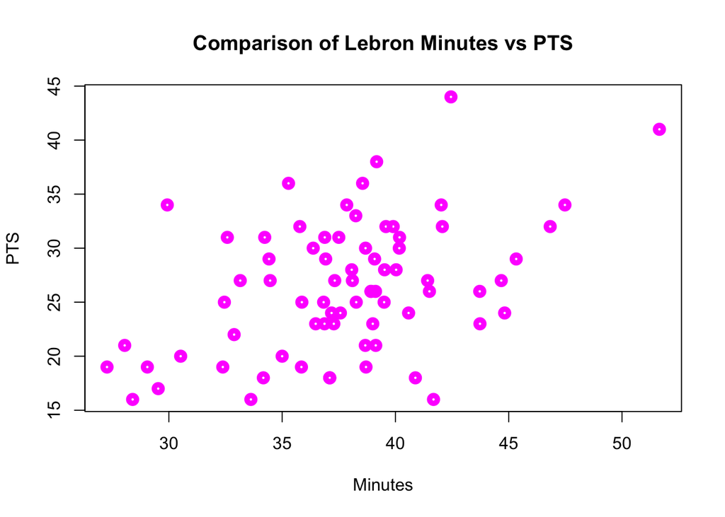

```r
# plot the two variables. Minutes and PTS
plot(james$Minutes, james$PTS, lwd=5, col="magenta1",
     main = "Comparison of Lebron Minutes vs PTS",
     xlab = "Minutes",
     ylab = "PTS")
```

### Question 3 (3 points)

For this question you will work with the `nba` data frame created in question 2.

Select two players. For each player, compute their field goal percentage and effective field goal percentage for all their games played. Use at least two descriptive statistics to determine which player had the better field goal percentage, and which player had the better effective field goal percentage for the 2016-2017 NBA season. Your answer should include an explanation.

Field Goal Percentage; the formula is `FG / FGA`.

Effective Field Goal Percentage; the formula is `(FG + 0.5 * X3P) / FGA`. This statistic adjusts for the fact that a 3-point field goal is worth one more point than a 2-point field goal. For example, suppose Player A goes 4 for 10 with 2 threes, while Player B goes 5 for 10 with 0 threes. Each player would have 10 points from field goals, and each would have the same effective field goal percentage (50%).

**(a) Get Kevin and James subset data**

```r
# Player 1: Lebron James
# Player 2: Kelvin Durant
james = nba[nba$Player =="LeBron James",]
durant = nba[nba$Player =="Kevin Durant",]
```

**(b) Find James and Kevin field goal percentage**

```r
# James Field Goal Percentage
james_field_goal_per <- james$FG/james$FGA
james_field_goal_per
```

```
 [1] 0.6428571 0.4375000 0.4375000 0.5000000 0.5454545 0.3913043 0.4705882
 [8] 0.5000000 0.3809524 0.6666667 0.6428571 0.5238095 0.4615385 0.4736842
[15] 0.5000000 0.3571429 0.5909091 0.4615385 0.7000000 0.5454545 0.7083333
[22] 0.5294118 0.5000000 0.4800000 0.5000000 0.4375000 0.5454545 0.5000000
[29] 0.4800000 0.4285714 0.5714286 0.7000000 0.6470588 0.5000000 0.4166667
[36] 0.5000000 0.3333333 0.6666667 0.6875000 0.5238095 0.5333333 0.7222222
[43] 0.5000000 0.4736842 0.7857143 0.6000000 0.6666667 0.5625000 0.4210526
[50] 0.6875000 0.7142857 0.7058824 0.6363636 0.6666667 0.4761905 0.5185185
[57] 0.5000000 0.5454545 0.5714286 0.6000000 0.5000000 0.6500000 0.5909091
[64] 0.6666667 0.6428571 0.4761905 0.4117647 0.5500000 0.6363636 0.5517241
[71] 0.5000000 0.6363636 0.8000000 0.5238095
```

```r
# Durant Field Goal Percentage
durant_field_goal_per <- durant$FG/durant$FGA
durant_field_goal_per
```

```
 [1] 0.6111111 0.4736842 0.6250000 0.6000000 0.6250000 0.6250000 0.4705882
 [8] 0.6250000 0.5000000 0.4761905 0.5238095 0.7692308 0.5882353 0.3333333
[15] 0.7333333 0.5789474 0.5882353 0.5000000 0.4285714 0.7142857 0.6428571
[22] 0.2941176 0.4666667 0.5384615 0.2857143 0.5263158 0.3888889 0.8461538
[29] 0.5714286 0.4347826 0.7222222 0.4782609 0.5333333 0.5000000 0.5263158
[36] 0.5625000 0.4117647 0.6000000 0.4761905 0.6666667 0.5625000 0.8125000
[43] 0.6315789 0.4166667 0.5217391 0.5500000 0.8181818 0.5000000 0.4117647
[50] 0.4444444 0.2000000 0.5625000 0.3571429 0.5714286 0.6250000 0.6666667
[57] 0.5333333 0.4705882 0.0000000 0.4000000 0.5000000 0.6875000
```

**(c) Find James and Kevin effective field goal percentage**

```r
james_eff_fgp <- (james$FG + 0.5 * james$X3P)/james$FGA
james_eff_fgp
```

```
 [1] 0.6428571 0.5000000 0.5000000 0.5416667 0.5681818 0.4130435 0.5294118
 [8] 0.5833333 0.4285714 0.7333333 0.6785714 0.5714286 0.5384615 0.5000000
[15] 0.5937500 0.3571429 0.6136364 0.5000000 0.7500000 0.5681818 0.8125000
[22] 0.5294118 0.5555556 0.5800000 0.5833333 0.4375000 0.6363636 0.5555556
[29] 0.5600000 0.4285714 0.5952381 0.7000000 0.7058824 0.5750000 0.5000000
[36] 0.5416667 0.3611111 0.6666667 0.7500000 0.5476190 0.5333333 0.7500000
[43] 0.5000000 0.5000000 0.8214286 0.7000000 0.8333333 0.5937500 0.4473684
[50] 0.7187500 0.7857143 0.8235294 0.6363636 0.7083333 0.5476190 0.6296296
[57] 0.5454545 0.5454545 0.6428571 0.7000000 0.5000000 0.7000000 0.6590909
[64] 0.6666667 0.6428571 0.4761905 0.4117647 0.5750000 0.7045455 0.6034483
[71] 0.5000000 0.6590909 0.8333333 0.5476190
```

```r
durant_eff_fgp <- (durant$FG + 0.5 * durant$X3P)/durant$FGA
durant_eff_fgp
```

```
 [1] 0.6388889 0.4736842 0.6875000 0.6000000 0.7708333 0.6875000 0.5000000
 [8] 0.7500000 0.5000000 0.5238095 0.5952381 0.8076923 0.7352941 0.3888889
[15] 0.8000000 0.6578947 0.6764706 0.5312500 0.4821429 0.7857143 0.6428571
[22] 0.3235294 0.5000000 0.6538462 0.3095238 0.5526316 0.4166667 1.0000000
[29] 0.5714286 0.4565217 0.8055556 0.5217391 0.6333333 0.5714286 0.5526316
[36] 0.6562500 0.4117647 0.6666667 0.5476190 0.7666667 0.6562500 0.9687500
[43] 0.6842105 0.4583333 0.5434783 0.5750000 0.9545455 0.5192308 0.4411765
[50] 0.5000000 0.2000000 0.5937500 0.4642857 0.6428571 0.6875000 0.7000000
[57] 0.6666667 0.5000000 0.0000000 0.4000000 0.5000000 0.8437500
```

**(d) Determine which player had better field goal percentage**

```r
# Get Lebron James mean of the FGP
jmean_fgp <-  mean(james_field_goal_per, na.rm = TRUE)
jmean_fgp <-
# Get Lebron James median of the FGP
jmedian_fgp <- median(james_field_goal_per, na.rm = TRUE)

# Get Kevin Durant mean of the FGP
dmean_fgp <- mean(durant_field_goal_per, na.rm = TRUE)
dmean_fgp
```

```
[1] 0.5339634
```

```r
# Get Kevin Durant median of the FGP
dmedian_fgp <- median(durant_field_goal_per, na.rm = TRUE)
dmedian_fgp
```

```
[1] 0.5333333
```

```r
# Compare the results
jmean_fgp > dmean_fgp
```

```
[1] FALSE
```

```r
jmedian_fgp > dmedian_fgp
```

```
[1] FALSE
```

**(d) Determine which player had better effective field goal percentage**

```r
# Print Lebron James mean of the EFGP
jmean_eff_fgp <- mean(james_eff_fgp, na.rm = TRUE)
jmean_eff_fgp
```

```
[1] 0.596974
```

```r
# Print Lebron James median of the EFGP
jmedian_eff_fgp <- median(james_eff_fgp, na.rm = TRUE)
jmedian_eff_fgp
```

```
[1] 0.5775
```

```r
# Print Kevin Durant mean of the EFGP
dmean_eff_fgp <- mean(durant_eff_fgp, na.rm = TRUE)
dmean_eff_fgp
```

```
[1] 0.5911814
```

```r
# Print Kevin Durant median of the EFGP
dmedian_eff_fgp <- median(durant_eff_fgp, na.rm = TRUE)
dmedian_eff_fgp
```

```
[1] 0.584375
```

```r
# Compare the results
jmean_eff_fgp > dmean_eff_fgp
```

```
[1] TRUE
```

```r
jmedian_eff_fgp > dmedian_eff_fgp
```

```
[1] FALSE
```

**Ans** *It seems that Lebron James had a higher average effective field goal percentage of 0.596974 than Kevin Durant who has 0.5911814. However, in terms of median field goal percentage, Durant scored higher than Lebron*

### Student Feedback

This part is optional. It will be available on all assignments. Feel free to answer on all, some, or none.

1. How is the course going for you in terms of pace and/or difficulty level?
2. Do you have any concerns or suggestions?
3. Please provide any other comments you may have.